# Data Wrangling Act

```python
import numpy as np
import pandas as pd
import requests
import matplotlib.pyplot as plt
import seaborn as sb
%matplotlib inline
```

## Data Gathering

```python
content = pd.read_csv('Content.csv',index_col=0)
```

```python
content.head()
```

|  | Content ID | User ID | Type | Category | URL |
| --- | --- | --- | --- | --- | --- |
| 0 | 97522e57-d9ab-4bd6-97bf-c24d952602d2 | 8d3cd87d-8a31-4935-9a4f-b319bfe05f31 | photo | Studying | https://socialbuzz.cdn.com/content/storage/975... |
| 1 | 9f737e0a-3cdd-4d29-9d24-753f4e3be810 | beb1f34e-7870-46d6-9fc7-2e12eb83ce43 | photo | healthy eating | https://socialbuzz.cdn.com/content/storage/9f7... |
| 2 | 230c4e4d-70c3-461d-b42c-ec09396efb3f | a5c65404-5894-4b87-82f2-d787cbee86b4 | photo | healthy eating | https://socialbuzz.cdn.com/content/storage/230... |
| 3 | 356fff80-da4d-4785-9f43-bc1261031dc6 | 9fb4ce88-fac1-406c-8544-1a899cee7aaf | photo | technology | https://socialbuzz.cdn.com/content/storage/356... |
| 4 | 01ab84dd-6364-4236-abbb-3f237db77180 | e206e31b-5f85-4964-b6ea-d7ee5324def1 | video | food | https://socialbuzz.cdn.com/content/storage/01a... |

```python
reactions = pd.read_csv('Reactions.csv',index_col=0)
```

```python
reactions.head()
```

|  | Content ID | User ID | Type | Datetime |
| --- | --- | --- | --- | --- |
| 0 | 97522e57-d9ab-4bd6-97bf-c24d952602d2 | NaN | NaN | 2021-04-22 15:17:15 |
| 1 | 97522e57-d9ab-4bd6-97bf-c24d952602d2 | 5d454588-283d-459d-915d-c48a2cb4c27f | disgust | 2020-11-07 09:43:50 |
| 2 | 97522e57-d9ab-4bd6-97bf-c24d952602d2 | 92b87fa5-f271-43e0-af66-84fac21052e6 | dislike | 2021-06-17 12:22:51 |
| 3 | 97522e57-d9ab-4bd6-97bf-c24d952602d2 | 163daa38-8b77-48c9-9af6-37a6c1447ac2 | scared | 2021-04-18 05:13:58 |
| 4 | 97522e57-d9ab-4bd6-97bf-c24d952602d2 | 34e8add9-0206-47fd-a501-037b994650a2 | disgust | 2021-01-06 19:13:01 |

```python
reactiontypes = pd.read_csv('ReactionTypes.csv',index_col=0)
```

```python
reactiontypes.head()
```

|  | Type | Sentiment | Score |
| --- | --- | --- | --- |
| 0 | heart | positive | 60 |
| 1 | want | positive | 70 |
| 2 | disgust | negative | 0 |
| 3 | hate | negative | 5 |
| 4 | interested | positive | 30 |

## Data Assessing

#### Content table(dataset)

```python
content
```

|  | Content ID | User ID | Type | Category | URL |
| --- | --- | --- | --- | --- | --- |
| 0 | 97522e57-d9ab-4bd6-97bf-c24d952602d2 | 8d3cd87d-8a31-4935-9a4f-b319bfe05f31 | photo | Studying | https://socialbuzz.cdn.com/content/storage/975... |
| 1 | 9f737e0a-3cdd-4d29-9d24-753f4e3be810 | beb1f34e-7870-46d6-9fc7-2e12eb83ce43 | photo | healthy eating | https://socialbuzz.cdn.com/content/storage/9f7... |
| 2 | 230c4e4d-70c3-461d-b42c-ec09396efb3f | a5c65404-5894-4b87-82f2-d787cbee86b4 | photo | healthy eating | https://socialbuzz.cdn.com/content/storage/230... |
| 3 | 356fff80-da4d-4785-9f43-bc1261031dc6 | 9fb4ce88-fac1-406c-8544-1a899cee7aaf | photo | technology | https://socialbuzz.cdn.com/content/storage/356... |
| 4 | 01ab84dd-6364-4236-abbb-3f237db77180 | e206e31b-5f85-4964-b6ea-d7ee5324def1 | video | food | https://socialbuzz.cdn.com/content/storage/01a... |
| ... | ... | ... | ... | ... | ... |
| 995 | b4cef9ef-627b-41d7-a051-5961b0204ebb | 5b62e10e-3c19-4d28-a57c-e9bdc3d6758d | video | public speaking | https://socialbuzz.cdn.com/content/storage/b4c... |
| 996 | 7a79f4e4-3b7d-44dc-bdef-bc990740252c | 4fe420fa-a193-4408-bd5d-62a020233609 | GIF | technology | https://socialbuzz.cdn.com/content/storage/7a7... |
| 997 | 435007a5-6261-4d8b-b0a4-55fdc189754b | 35d6a1f3-e358-4d4b-8074-05f3b7f35c2a | audio | veganism | https://socialbuzz.cdn.com/content/storage/435... |
| 998 | 4e4c9690-c013-4ee7-9e66-943d8cbd27b7 | b9bcd994-f000-4f6b-87fc-caae08acfaa1 | GIF | culture | https://socialbuzz.cdn.com/content/storage/4e4... |
| 999 | 75d6b589-7fae-4a6d-b0d0-752845150e56 | b8c653b5-0118-4d7e-9bde-07c2de90f0ff | audio | technology | https://socialbuzz.cdn.com/content/storage/75d... |

1000 rows × 5 columns

```python
# Return a coincise summary of the table- datatypes, non-null values, column names etc.
content.info()
```

```
<class 'pandas.core.frame.DataFrame'>
Int64Index: 1000 entries, 0 to 999
Data columns (total 5 columns):
 #   Column      Non-Null Count  Dtype
---  ------      --------------  -----
 0   Content ID  1000 non-null   object
 1   User ID     1000 non-null   object
 2   Type        1000 non-null   object
 3   Category    1000 non-null   object
 4   URL         1000 non-null   object
dtypes: object(5)
memory usage: 46.9+ KB
```

```python
# checks for missing entries
content.isna()
```

|  | Content ID | User ID | Type | Category | URL |
| --- | --- | --- | --- | --- | --- |
| 0 | False | False | False | False | False |
| 1 | False | False | False | False | False |
| 2 | False | False | False | False | False |
| 3 | False | False | False | False | False |
| 4 | False | False | False | False | False |
| ... | ... | ... | ... | ... | ... |
| 995 | False | False | False | False | False |
| 996 | False | False | False | False | False |
| 997 | False | False | False | False | False |
| 998 | False | False | False | False | False |
| 999 | False | False | False | False | False |

1000 rows × 5 columns

```python
content.nunique()
```

```
Content ID    1000
User ID        446
Type             4
Category        41
URL           1000
dtype: int64
```

```python
# checks for duplicates
sum(content.duplicated())
```

```
0
```

#### Reactions table dataset

```python
reactions
```

|  | Content ID | User ID | Type | Datetime |
| --- | --- | --- | --- | --- |
| 0 | 97522e57-d9ab-4bd6-97bf-c24d952602d2 | NaN | NaN | 2021-04-22 15:17:15 |
| 1 | 97522e57-d9ab-4bd6-97bf-c24d952602d2 | 5d454588-283d-459d-915d-c48a2cb4c27f | disgust | 2020-11-07 09:43:50 |
| 2 | 97522e57-d9ab-4bd6-97bf-c24d952602d2 | 92b87fa5-f271-43e0-af66-84fac21052e6 | dislike | 2021-06-17 12:22:51 |
| 3 | 97522e57-d9ab-4bd6-97bf-c24d952602d2 | 163daa38-8b77-48c9-9af6-37a6c1447ac2 | scared | 2021-04-18 05:13:58 |
| 4 | 97522e57-d9ab-4bd6-97bf-c24d952602d2 | 34e8add9-0206-47fd-a501-037b994650a2 | disgust | 2021-01-06 19:13:01 |
| ... | ... | ... | ... | ... |
| 25548 | 75d6b589-7fae-4a6d-b0d0-752845150e56 | 80c9ce48-46f9-4f5e-b3ca-3b698fc2e949 | dislike | 2020-06-27 09:46:48 |
| 25549 | 75d6b589-7fae-4a6d-b0d0-752845150e56 | 2bd9c167-e06c-47c1-a978-3403d6724606 | intrigued | 2021-02-16 17:17:02 |
| 25550 | 75d6b589-7fae-4a6d-b0d0-752845150e56 | NaN | interested | 2020-09-12 03:54:58 |
| 25551 | 75d6b589-7fae-4a6d-b0d0-752845150e56 | 5ffd8b51-164e-47e2-885e-8b8c46eb63ed | worried | 2020-11-04 20:08:31 |
| 25552 | 75d6b589-7fae-4a6d-b0d0-752845150e56 | 4edc3d1a-a7d9-4db6-89c3-f784d9954172 | cherish | 2021-01-04 04:55:11 |

25553 rows × 4 columns

```python
reactions.head(10)
```

|  | Content ID | User ID | Type | Datetime |
| --- | --- | --- | --- | --- |
| 0 | 97522e57-d9ab-4bd6-97bf-c24d952602d2 | NaN | NaN | 2021-04-22 15:17:15 |
| 1 | 97522e57-d9ab-4bd6-97bf-c24d952602d2 | 5d454588-283d-459d-915d-c48a2cb4c27f | disgust | 2020-11-07 09:43:50 |
| 2 | 97522e57-d9ab-4bd6-97bf-c24d952602d2 | 92b87fa5-f271-43e0-af66-84fac21052e6 | dislike | 2021-06-17 12:22:51 |
| 3 | 97522e57-d9ab-4bd6-97bf-c24d952602d2 | 163daa38-8b77-48c9-9af6-37a6c1447ac2 | scared | 2021-04-18 05:13:58 |
| 4 | 97522e57-d9ab-4bd6-97bf-c24d952602d2 | 34e8add9-0206-47fd-a501-037b994650a2 | disgust | 2021-01-06 19:13:01 |
| 5 | 97522e57-d9ab-4bd6-97bf-c24d952602d2 | 9b6d35f9-5e15-4cd0-a8d7-b1f3340e02c4 | interested | 2020-08-23 12:25:58 |
| 6 | 97522e57-d9ab-4bd6-97bf-c24d952602d2 | 7918d465-0953-4f20-9e28-539e74c82e2f | peeking | 2020-12-07 06:27:54 |
| 7 | 97522e57-d9ab-4bd6-97bf-c24d952602d2 | fa3e42f0-71d8-455f-b024-e52d5c27a145 | cherish | 2021-04-11 17:35:49 |
| 8 | 97522e57-d9ab-4bd6-97bf-c24d952602d2 | b0c22f82-b882-4394-bf27-6dfadf26e5c2 | hate | 2021-01-27 08:32:09 |
| 9 | 97522e57-d9ab-4bd6-97bf-c24d952602d2 | 1932a904-86ba-4438-bb52-b7e6516a4019 | peeking | 2021-04-01 22:54:23 |

```python
# Return a coincise summary of the table- datatypes, non-null values, column names etc.
reactions.info()
```

```
<class 'pandas.core.frame.DataFrame'>
Int64Index: 25553 entries, 0 to 25552
Data columns (total 4 columns):
 #   Column      Non-Null Count  Dtype
---  ------      --------------  -----
 0   Content ID  25553 non-null  object
 1   User ID     22534 non-null  object
 2   Type        24573 non-null  object
 3   Datetime    25553 non-null  object
dtypes: object(4)
memory usage: 998.2+ KB
```

```python
# checks for number of null entries
len(reactions[reactions['User ID'].isna()])
```

```
3019
```

```python
# checks for number of null entries
len(reactions[reactions['Type'].isna()])
```

```
980
```

```python
reactions.Type.value_counts()
```

```
heart          1622
scared         1572
peeking        1559
hate           1552
interested     1549
dislike        1548
adore          1548
want           1539
love           1534
disgust        1526
like           1520
super love     1519
indifferent    1512
cherish        1501
worried        1497
intrigued      1475
Name: Type, dtype: int64
```

```python
# checks for duplicates in table
sum(reactions.duplicated())
```

```
0
```

```python
# checks for missing entries
reactions.isna()
```

|  | Content ID | User ID | Type | Datetime |
| --- | --- | --- | --- | --- |
| 0 | False | True | True | False |
| 1 | False | False | False | False |
| 2 | False | False | False | False |
| 3 | False | False | False | False |
| 4 | False | False | False | False |
| ... | ... | ... | ... | ... |
| 25548 | False | False | False | False |
| 25549 | False | False | False | False |
| 25550 | False | True | False | False |
| 25551 | False | False | False | False |
| 25552 | False | False | False | False |

25553 rows × 4 columns

```python
# returns a series containing counts of unique rows in dataset
content.URL.value_counts()
```

```
https://socialbuzz.cdn.com/content/storage/97522e57-d9ab-4bd6-97bf-c24d952602d2    1
https://socialbuzz.cdn.com/content/storage/d0c1d7f4-7735-49a9-ab6b-2cdb2338a609    1
https://socialbuzz.cdn.com/content/storage/22cdf77b-00c8-41c3-ad59-333c3e751e2c    1
https://socialbuzz.cdn.com/content/storage/28b8c278-a125-4295-98dd-5f8d45c3200b    1
https://socialbuzz.cdn.com/content/storage/e1792fe6-28e0-49fc-8b01-0e027461d8b5    1
                                                                                  ..
https://socialbuzz.cdn.com/content/storage/16fb5dcb-4349-4831-acf2-8c116ad7dae5    1
https://socialbuzz.cdn.com/content/storage/0d5eb9fd-879d-4716-aebc-840f7b1b7e9f    1
https://socialbuzz.cdn.com/content/storage/e4827a5c-c604-4aad-b7ed-b396b3601b74    1
https://socialbuzz.cdn.com/content/storage/abecd821-ad3d-43b0-a550-aadd9d267072    1
https://socialbuzz.cdn.com/content/storage/75d6b589-7fae-4a6d-b0d0-752845150e56    1
Name: URL, Length: 1000, dtype: int64
```

```python
reactiontypes
```

|  | Type | Sentiment | Score |
| --- | --- | --- | --- |
| 0 | heart | positive | 60 |
| 1 | want | positive | 70 |
| 2 | disgust | negative | 0 |
| 3 | hate | negative | 5 |
| 4 | interested | positive | 30 |
| 5 | indifferent | neutral | 20 |
| 6 | love | positive | 65 |
| 7 | super love | positive | 75 |
| 8 | cherish | positive | 70 |
| 9 | adore | positive | 72 |
| 10 | like | positive | 50 |
| 11 | dislike | negative | 10 |
| 12 | intrigued | positive | 45 |
| 13 | peeking | neutral | 35 |
| 14 | scared | negative | 15 |
| 15 | worried | negative | 12 |

```python
# Return a coincise summary of the table- datatypes, non-null values, column names etc.
reactiontypes.info()
```

```
<class 'pandas.core.frame.DataFrame'>
Int64Index: 16 entries, 0 to 15
Data columns (total 3 columns):
 #   Column     Non-Null Count  Dtype
---  ------     --------------  -----
 0   Type       16 non-null     object
 1   Sentiment  16 non-null     object
 2   Score      16 non-null     int64
dtypes: int64(1), object(2)
memory usage: 512.0+ bytes
```

```python
# checks for duplicates in table
sum(reactiontypes.duplicated())
```

```
0
```

```python
# checks for missing entries
reactiontypes.isna()
```

|  | Type | Sentiment | Score |
| --- | --- | --- | --- |
| 0 | False | False | False |
| 1 | False | False | False |
| 2 | False | False | False |
| 3 | False | False | False |
| 4 | False | False | False |
| 5 | False | False | False |
| 6 | False | False | False |
| 7 | False | False | False |
| 8 | False | False | False |
| 9 | False | False | False |
| 10 | False | False | False |
| 11 | False | False | False |
| 12 | False | False | False |
| 13 | False | False | False |
| 14 | False | False | False |
| 15 | False | False | False |

## Issues

#### Data Quality

- Missing entries in `reactions`(User ID, Type) table
- Wrong datatype for datetime in `reactions` table
- Multiple representations of category data entry in `content` table - sometimes quotes, sometimes no quotes, sometimes lowercase, sometimes uppercase
- Use of non-unique column names with varied values in `content` table(Type) and `reactions`/`reactiontypes`(Type) table
- Non-descriptive column headers(Type in Content table and Type in Reactions table
- Inconsistent column headers naming format- sometimes lower case, sometimes upper case(URL), whitespace in column headers (User ID)

#### Tidiness

# Data Cleaning

```python
content_clean=content.copy()
reactions_clean=reactions.copy()
reactiontypes_clean = reactiontypes.copy()
```

##### Issue1: Missing data in User ID and Type column - No need to clean as it will be dropped

##### Issue2: Wrong datatype

`reactions`: Datetime should be timestamp, not a string

#### Define

Convert Datetime from string to datetime datatype

#### Code

```python
reactions_clean['Datetime'] = pd.to_datetime(reactions_clean['Datetime'])
```

#### Test

```python
# confirm that datetime is now datetime datatype
reactions_clean.Datetime.dtype
```

```
dtype('<M8[ns]')
```

```python
reactions_clean.info()
```

```
<class 'pandas.core.frame.DataFrame'>
Int64Index: 25553 entries, 0 to 25552
Data columns (total 4 columns):
 #   Column      Non-Null Count  Dtype
---  ------      --------------  -----
 0   Content ID  25553 non-null  object
 1   User ID     22534 non-null  object
 2   Type        24573 non-null  object
 3   Datetime    25553 non-null  datetime64[ns]
dtypes: datetime64[ns](1), object(3)
memory usage: 998.2+ KB
```

```python
content_clean
```

|  | Content ID | User ID | Type | Category | URL |
| --- | --- | --- | --- | --- | --- |
| 0 | 97522e57-d9ab-4bd6-97bf-c24d952602d2 | 8d3cd87d-8a31-4935-9a4f-b319bfe05f31 | photo | Studying | https://socialbuzz.cdn.com/content/storage/975... |
| 1 | 9f737e0a-3cdd-4d29-9d24-753f4e3be810 | beb1f34e-7870-46d6-9fc7-2e12eb83ce43 | photo | healthy eating | https://socialbuzz.cdn.com/content/storage/9f7... |
| 2 | 230c4e4d-70c3-461d-b42c-ec09396efb3f | a5c65404-5894-4b87-82f2-d787cbee86b4 | photo | healthy eating | https://socialbuzz.cdn.com/content/storage/230... |
| 3 | 356fff80-da4d-4785-9f43-bc1261031dc6 | 9fb4ce88-fac1-406c-8544-1a899cee7aaf | photo | technology | https://socialbuzz.cdn.com/content/storage/356... |
| 4 | 01ab84dd-6364-4236-abbb-3f237db77180 | e206e31b-5f85-4964-b6ea-d7ee5324def1 | video | food | https://socialbuzz.cdn.com/content/storage/01a... |
| ... | ... | ... | ... | ... | ... |
| 995 | b4cef9ef-627b-41d7-a051-5961b0204ebb | 5b62e10e-3c19-4d28-a57c-e9bdc3d6758d | video | public speaking | https://socialbuzz.cdn.com/content/storage/b4c... |
| 996 | 7a79f4e4-3b7d-44dc-bdef-bc990740252c | 4fe420fa-a193-4408-bd5d-62a020233609 | GIF | technology | https://socialbuzz.cdn.com/content/storage/7a7... |
| 997 | 435007a5-6261-4d8b-b0a4-55fdc189754b | 35d6a1f3-e358-4d4b-8074-05f3b7f35c2a | audio | veganism | https://socialbuzz.cdn.com/content/storage/435... |
| 998 | 4e4c9690-c013-4ee7-9e66-943d8cbd27b7 | b9bcd994-f000-4f6b-87fc-caae08acfaa1 | GIF | culture | https://socialbuzz.cdn.com/content/storage/4e4... |
| 999 | 75d6b589-7fae-4a6d-b0d0-752845150e56 | b8c653b5-0118-4d7e-9bde-07c2de90f0ff | audio | technology | https://socialbuzz.cdn.com/content/storage/75d... |

1000 rows × 5 columns

##### Issue 3: Multiple representations of column entries in Category column

First remove double quotes in category column entries then convert all uppercase entries to lower case entries to remove multiple representations

`content`: double quotes are present in Category column entries

#### Define

Remove double quotes from Category column entries

#### Code

```python
# remove double quotes in category column entrie
content_clean['Category'] = content_clean['Category'].apply(lambda x: x.replace('"', ''))
```

```python
# convert all uppercase entries to lower case entries to remove multiple representations
content_clean['Category'] = content_clean['Category'].str.lower()
```

#### Test

```python
# confirm that there are no multiple representations of column entries in Content Category
content_clean.Category.value_counts()
```

```
technology         73
animals            72
travel             69
science            68
culture            67
fitness            66
food               64
soccer             64
healthy eating     62
cooking            61
tennis             59
education          59
studying           58
dogs               58
public speaking    50
veganism           50
Name: Category, dtype: int64
```

```python
content_clean.Category.nunique()
```

```
16
```

##### Issue 4, 5 & 6: Inconsistent column names

`content`:

#### Define

Rename column names to ensure that all column names follow a consistent pattern for easy readability and useability

#### Code

```python
content_clean.rename(columns={'Content ID':'content_id','User ID':'user_id','Type':'c_type','Category':'c_category','URL':'c_url'}, inplace=True)
content_clean.info()
```

```
<class 'pandas.core.frame.DataFrame'>
Int64Index: 1000 entries, 0 to 999
Data columns (total 5 columns):
 #   Column      Non-Null Count  Dtype
---  ------      --------------  -----
 0   content_id  1000 non-null   object
 1   user_id     1000 non-null   object
 2   c_type      1000 non-null   object
 3   c_category  1000 non-null   object
 4   c_url       1000 non-null   object
dtypes: object(5)
memory usage: 46.9+ KB
```

```python
reactions_clean.rename(columns={'Content ID':'content_id','User ID':'user_id','Type':'r_type','Datetime':'datetime'}, inplace=True)
reactions_clean.info()
```

```
<class 'pandas.core.frame.DataFrame'>
Int64Index: 25553 entries, 0 to 25552
Data columns (total 4 columns):
 #   Column      Non-Null Count  Dtype
---  ------      --------------  -----
 0   content_id  25553 non-null  object
 1   user_id     22534 non-null  object
 2   r_type      24573 non-null  object
 3   datetime    25553 non-null  datetime64[ns]
dtypes: datetime64[ns](1), object(3)
memory usage: 998.2+ KB
```

```python
reactiontypes_clean.rename(columns={'Score':'r_score','Sentiment':'r_sentiment','Type':'r_type'}, inplace=True)
reactiontypes_clean.info()
```

```
<class 'pandas.core.frame.DataFrame'>
Int64Index: 16 entries, 0 to 15
Data columns (total 3 columns):
 #   Column       Non-Null Count  Dtype
---  ------       --------------  -----
 0   r_type       16 non-null     object
 1   r_sentiment  16 non-null     object
 2   r_score      16 non-null     int64
dtypes: int64(1), object(2)
memory usage: 512.0+ bytes
```

#### Issue7: Seperate tables need to be merged

#### Define

Tables should be merged into one table

- Reactions table is used as the base table since it has primary columns of content id and reaction type

#### Code

```python
# Merge content table to reaction table to content_reaction table
content_reaction =pd.merge(reactions_clean, content_clean, how='inner', on=['content_id'])
```

```python
# Merge content_reaction to reactiontypes table
content_reaction = pd.merge(content_reaction, reactiontypes_clean, how='inner', on =['r_type'])
```

#### Test

```python
# Confirm Merge was executed correctly
content_reaction
```

|  | content_id | user_id_x | r_type | datetime | user_id_y | c_type | c_category | c_url | r_sentiment | r_score |
| --- | --- | --- | --- | --- | --- | --- | --- | --- | --- | --- |
| 0 | 97522e57-d9ab-4bd6-97bf-c24d952602d2 | 5d454588-283d-459d-915d-c48a2cb4c27f | disgust | 2020-11-07 09:43:50 | 8d3cd87d-8a31-4935-9a4f-b319bfe05f31 | photo | studying | https://socialbuzz.cdn.com/content/storage/975... | negative | 0 |
| 1 | 97522e57-d9ab-4bd6-97bf-c24d952602d2 | 34e8add9-0206-47fd-a501-037b994650a2 | disgust | 2021-01-06 19:13:01 | 8d3cd87d-8a31-4935-9a4f-b319bfe05f31 | photo | studying | https://socialbuzz.cdn.com/content/storage/975... | negative | 0 |
| 2 | 97522e57-d9ab-4bd6-97bf-c24d952602d2 | 13c06e7e-833d-47eb-a790-5e09ccfd8d2c | disgust | 2021-04-09 02:46:20 | 8d3cd87d-8a31-4935-9a4f-b319bfe05f31 | photo | studying | https://socialbuzz.cdn.com/content/storage/975... | negative | 0 |
| 3 | 9f737e0a-3cdd-4d29-9d24-753f4e3be810 | 8b49caad-bcc5-43de-bf40-34a66ff8805c | disgust | 2021-03-28 21:15:26 | beb1f34e-7870-46d6-9fc7-2e12eb83ce43 | photo | healthy eating | https://socialbuzz.cdn.com/content/storage/9f7... | negative | 0 |
| 4 | 230c4e4d-70c3-461d-b42c-ec09396efb3f | ef147ea5-9696-44d5-b6c2-a43f62fd8ce2 | disgust | 2020-08-04 05:40:33 | a5c65404-5894-4b87-82f2-d787cbee86b4 | photo | healthy eating | https://socialbuzz.cdn.com/content/storage/230... | negative | 0 |
| ... | ... | ... | ... | ... | ... | ... | ... | ... | ... | ... |
| 24568 | 435007a5-6261-4d8b-b0a4-55fdc189754b | d51a3403-8bab-4d88-af4f-a429c6d8c168 | adore | 2020-10-04 22:26:33 | 35d6a1f3-e358-4d4b-8074-05f3b7f35c2a | audio | veganism | https://socialbuzz.cdn.com/content/storage/435... | positive | 72 |
| 24569 | 435007a5-6261-4d8b-b0a4-55fdc189754b | 3663e3e6-3d5c-4ed9-a6af-1e680ec5f34b | adore | 2020-09-18 10:50:50 | 35d6a1f3-e358-4d4b-8074-05f3b7f35c2a | audio | veganism | https://socialbuzz.cdn.com/content/storage/435... | positive | 72 |
| 24570 | 4e4c9690-c013-4ee7-9e66-943d8cbd27b7 | 89572273-761e-46f3-8b99-1689d98aac90 | adore | 2020-10-31 03:58:44 | b9bcd994-f000-4f6b-87fc-caae08acfaa1 | GIF | culture | https://socialbuzz.cdn.com/content/storage/4e4... | positive | 72 |
| 24571 | 4e4c9690-c013-4ee7-9e66-943d8cbd27b7 | 7bf3ce80-784e-42a0-b06a-dbbd1e31a9b7 | adore | 2020-06-25 15:12:29 | b9bcd994-f000-4f6b-87fc-caae08acfaa1 | GIF | culture | https://socialbuzz.cdn.com/content/storage/4e4... | positive | 72 |
| 24572 | 4e4c9690-c013-4ee7-9e66-943d8cbd27b7 | dcc6000c-ba92-472c-8bc1-9e9ca30b475b | adore | 2020-12-17 16:32:57 | b9bcd994-f000-4f6b-87fc-caae08acfaa1 | GIF | culture | https://socialbuzz.cdn.com/content/storage/4e4... | positive | 72 |

24573 rows × 10 columns

```python
content_reaction.info()
```

```
<class 'pandas.core.frame.DataFrame'>
Int64Index: 24573 entries, 0 to 24572
Data columns (total 10 columns):
 #   Column       Non-Null Count  Dtype
---  ------       --------------  -----
 0   content_id   24573 non-null  object
 1   user_id_x    22534 non-null  object
 2   r_type       24573 non-null  object
 3   datetime     24573 non-null  datetime64[ns]
 4   user_id_y    24573 non-null  object
 5   c_type       24573 non-null  object
 6   c_category   24573 non-null  object
 7   c_url        24573 non-null  object
 8   r_sentiment  24573 non-null  object
 9   r_score      24573 non-null  int64
dtypes: datetime64[ns](1), int64(1), object(8)
memory usage: 2.1+ MB
```

##### Issue 8 Extraneous Columns

user_id columns need to be dropped as it is irrelevant to the problem

#### Define

Drop extraneous columns

#### Code

```python
content_reaction.drop(['user_id_x', 'user_id_y','c_url'], axis=1, inplace = True)
```

#### Test

```python
# Confirm that dropped columns are gone
content_reaction.head()
```

|  | content_id | r_type | datetime | c_type | c_category | r_sentiment | r_score |
| --- | --- | --- | --- | --- | --- | --- | --- |
| 0 | 97522e57-d9ab-4bd6-97bf-c24d952602d2 | disgust | 2020-11-07 09:43:50 | photo | studying | negative | 0 |
| 1 | 97522e57-d9ab-4bd6-97bf-c24d952602d2 | disgust | 2021-01-06 19:13:01 | photo | studying | negative | 0 |
| 2 | 97522e57-d9ab-4bd6-97bf-c24d952602d2 | disgust | 2021-04-09 02:46:20 | photo | studying | negative | 0 |
| 3 | 9f737e0a-3cdd-4d29-9d24-753f4e3be810 | disgust | 2021-03-28 21:15:26 | photo | healthy eating | negative | 0 |
| 4 | 230c4e4d-70c3-461d-b42c-ec09396efb3f | disgust | 2020-08-04 05:40:33 | photo | healthy eating | negative | 0 |

```python
content_reaction.info()
```

```
<class 'pandas.core.frame.DataFrame'>
Int64Index: 24573 entries, 0 to 24572
Data columns (total 7 columns):
 #   Column       Non-Null Count  Dtype
---  ------       --------------  -----
 0   content_id   24573 non-null  object
 1   r_type       24573 non-null  object
 2   datetime     24573 non-null  datetime64[ns]
 3   c_type       24573 non-null  object
 4   c_category   24573 non-null  object
 5   r_sentiment  24573 non-null  object
 6   r_score      24573 non-null  int64
dtypes: datetime64[ns](1), int64(1), object(5)
memory usage: 1.5+ MB
```

## Data Storing

```python
content_reaction.to_csv('socialbuzz_content_master.csv',encoding='utf-8')
```

## Exploratory Data Analysis

```python
socialbuzz = pd.read_csv('socialbuzz_content_master.csv',index_col=0)
socialbuzz.head()
```

|  | content_id | r_type | datetime | c_type | c_category | r_sentiment | r_score |
| --- | --- | --- | --- | --- | --- | --- | --- |
| 0 | 97522e57-d9ab-4bd6-97bf-c24d952602d2 | disgust | 2020-11-07 09:43:50 | photo | studying | negative | 0 |
| 1 | 97522e57-d9ab-4bd6-97bf-c24d952602d2 | disgust | 2021-01-06 19:13:01 | photo | studying | negative | 0 |
| 2 | 97522e57-d9ab-4bd6-97bf-c24d952602d2 | disgust | 2021-04-09 02:46:20 | photo | studying | negative | 0 |
| 3 | 9f737e0a-3cdd-4d29-9d24-753f4e3be810 | disgust | 2021-03-28 21:15:26 | photo | healthy eating | negative | 0 |
| 4 | 230c4e4d-70c3-461d-b42c-ec09396efb3f | disgust | 2020-08-04 05:40:33 | photo | healthy eating | negative | 0 |

```python
socialbuzz.info()
```

```
<class 'pandas.core.frame.DataFrame'>
Int64Index: 24573 entries, 0 to 24572
Data columns (total 7 columns):
 #   Column       Non-Null Count  Dtype
---  ------       --------------  -----
 0   content_id   24573 non-null  object
 1   r_type       24573 non-null  object
 2   datetime     24573 non-null  object
 3   c_type       24573 non-null  object
 4   c_category   24573 non-null  object
 5   r_sentiment  24573 non-null  object
 6   r_score      24573 non-null  int64
dtypes: int64(1), object(6)
memory usage: 1.5+ MB
```

```python
socialbuzz.describe()
```

|  | r_score |
| --- | --- |
| count | 24573.000000 |
| mean | 39.622553 |
| std | 26.043011 |
| min | 0.000000 |
| 25% | 15.000000 |
| 50% | 35.000000 |
| 75% | 65.000000 |
| max | 75.000000 |

```python
socialbuzz.describe()
```

|  | r_score |
| --- | --- |
| count | 24573.000000 |
| mean | 39.622553 |
| std | 26.043011 |
| min | 0.000000 |
| 25% | 15.000000 |
| 50% | 35.000000 |
| 75% | 65.000000 |
| max | 75.000000 |

```python
socialbuzz.describe(include=['O'])
```

|  | content_id | r_type | datetime | c_type | c_category | r_sentiment |
| --- | --- | --- | --- | --- | --- | --- |
| count | 24573 | 24573 | 24573 | 24573 | 24573 | 24573 |
| unique | 962 | 16 | 24562 | 4 | 16 | 3 |
| top | d90a34f1-60ed-4a79-b7bf-fd22efa12e4c | heart | 2020-07-23 09:21:02 | photo | animals | positive |
| freq | 48 | 1622 | 2 | 6589 | 1897 | 13807 |

```python
socialbuzz.value_counts(['c_category','r_score'])
```

```
c_category       r_score
animals          70         247
culture          70         235
science          70         229
food             70         229
technology       70         227
                           ...
veganism         45          68
public speaking  35          65
veganism         0           65
dogs             12          62
public speaking  5           61
Length: 240, dtype: int64
```

```python
socialbuzz.value_counts(['c_category','r_type'])
```

```
c_category       r_type
animals          scared     132
food             hate       130
technology       adore      129
animals          peeking    129
                 hate       128
                           ...
veganism         disgust     65
public speaking  peeking     65
                 cherish     65
dogs             worried     62
public speaking  hate        61
Length: 256, dtype: int64
```

```python
socialbuzz.value_counts(['r_type','r_score'])
```

```
r_type       r_score
heart        60         1622
scared       15         1572
peeking      35         1559
hate         5          1552
interested   30         1549
adore        72         1548
dislike      10         1548
want         70         1539
love         65         1534
disgust      0          1526
like         50         1520
super love   75         1519
indifferent  20         1512
cherish      70         1501
worried      12         1497
intrigued    45         1475
dtype: int64
```

```python
len(socialbuzz.c_category)
```

```
24573
```

```python
socialbuzz.r_score.value_counts()
```

```
70    3040
60    1622
15    1572
35    1559
5     1552
30    1549
10    1548
72    1548
65    1534
0     1526
50    1520
75    1519
20    1512
12    1497
45    1475
Name: r_score, dtype: int64
```

### Distribution of content category

##### Question: How many unique categories are there?

```python
socialbuzz.c_category.nunique()
```

```
16
```

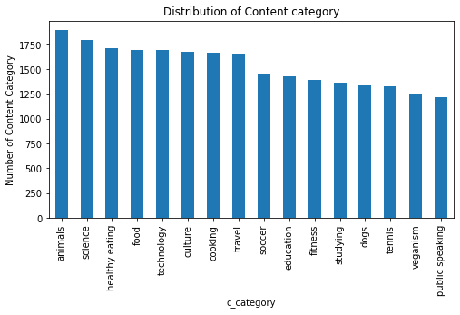

```python
socialbuzz.c_category.value_counts().plot.bar(figsize=(8,4), title='Distribution of Content category')
plt.xlabel('c_category',fontsize=10)
plt.ylabel('Number of Content Category', fontsize=10);
```

```python
socialbuzz.c_category.value_counts()
```

```
animals            1897
science            1796
healthy eating     1717
food               1699
technology         1698
culture            1676
cooking            1664
travel             1647
soccer             1457
education          1433
fitness            1395
studying           1363
dogs               1338
tennis             1328
veganism           1248
public speaking    1217
Name: c_category, dtype: int64
```

### Distribution of reaction score

```python
socialbuzz.r_score.nunique()
```

```
15
```

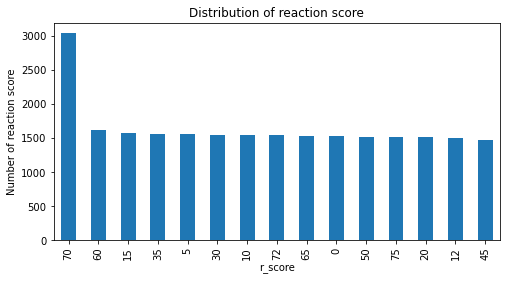

```python
socialbuzz.r_score.value_counts().plot.bar(figsize=(8,4), title='Distribution of reaction score')
plt.xlabel('r_score',fontsize=10)
plt.ylabel('Number of reaction score', fontsize=10);
```

```python
socialbuzz.r_score.value_counts()
```

```
70    3040
60    1622
15    1572
35    1559
5     1552
30    1549
10    1548
72    1548
65    1534
0     1526
50    1520
75    1519
20    1512
12    1497
45    1475
Name: r_score, dtype: int64
```

```python
socialbuzz.r_score.describe()
```

```
count    24573.000000
mean        39.622553
std         26.043011
min          0.000000
25%         15.000000
50%         35.000000
75%         65.000000
max         75.000000
Name: r_score, dtype: float64
```

### Distribution of reaction types

```python
socialbuzz.r_type.nunique()
```

```
16
```

```python
socialbuzz.r_type.value_counts()
```

```
heart          1622
scared         1572
peeking        1559
hate           1552
interested     1549
dislike        1548
adore          1548
want           1539
love           1534
disgust        1526
like           1520
super love     1519
indifferent    1512
cherish        1501
worried        1497
intrigued      1475
Name: r_type, dtype: int64
```

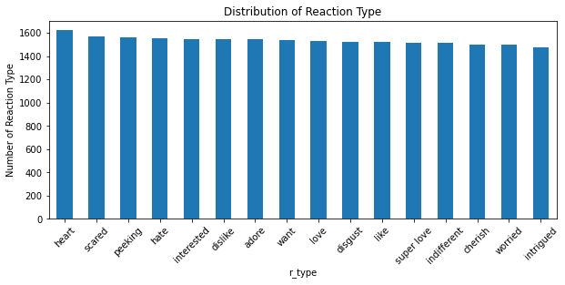

```python
socialbuzz.r_type.value_counts().plot.bar(figsize=(10,4), title='Distribution of Reaction Type')
plt.xlabel('r_type',fontsize=10)
plt.ylabel('Number of Reaction Type', fontsize=10)
plt.xticks(rotation=45);
```

### Distribution of post month

```python
socialbuzz.info()
```

```
<class 'pandas.core.frame.DataFrame'>
Int64Index: 24573 entries, 0 to 24572
Data columns (total 7 columns):
 #   Column       Non-Null Count  Dtype
---  ------       --------------  -----
 0   content_id   24573 non-null  object
 1   r_type       24573 non-null  object
 2   datetime     24573 non-null  object
 3   c_type       24573 non-null  object
 4   c_category   24573 non-null  object
 5   r_sentiment  24573 non-null  object
 6   r_score      24573 non-null  int64
dtypes: int64(1), object(6)
memory usage: 1.5+ MB
```

```python
socialbuzz.datetime.nunique()
```

```
24562
```

```python
socialbuzz['datetime'] = pd.to_datetime(socialbuzz['datetime'])
```

```python
# extract month from datetime variable

socialbuzz['r_monthname']=socialbuzz['datetime'].dt.month_name()
```

```python
socialbuzz.info()
```

```
<class 'pandas.core.frame.DataFrame'>
Int64Index: 24573 entries, 0 to 24572
Data columns (total 8 columns):
 #   Column       Non-Null Count  Dtype
---  ------       --------------  -----
 0   content_id   24573 non-null  object
 1   r_type       24573 non-null  object
 2   datetime     24573 non-null  datetime64[ns]
 3   c_type       24573 non-null  object
 4   c_category   24573 non-null  object
 5   r_sentiment  24573 non-null  object
 6   r_score      24573 non-null  int64
 7   r_monthname  24573 non-null  object
dtypes: datetime64[ns](1), int64(1), object(6)
memory usage: 1.7+ MB
```

```python
# converting reaction month from a plain object type into an ordered categorical type.

months=['January','February','March','April','May','June','July','August','September','October','November','December']
month=pd.api.types.CategoricalDtype(ordered=True,categories=months)
socialbuzz['r_monthname']=socialbuzz['r_monthname'].astype(month);
```

```
I've used pandas .astype() to convert the r_monthname variable  from a plain object type into an ordered categorical type. My bar chart shows the most posts happened in May and least in February
```

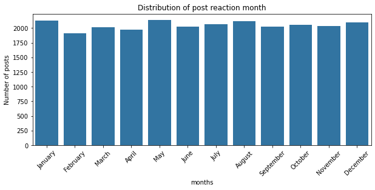

```python
def monthname():
    sol_string = ["I've used pandas .astype() to convert the r_monthname variable ",
                  "from a plain object type into an ordered categorical type. My bar chart shows the most posts",
                  "happened in May and least in February"]
    print((" ").join(sol_string))
    fig, ax=plt.subplots(figsize=[10,4])

    base_color = sb.color_palette()[0]
    sb.countplot(data =socialbuzz, x = 'r_monthname', color = base_color)
    plt.xticks(rotation=45)
    ax.set(ylabel='Number of posts', xlabel ='months')
    plt.title('Distribution of post reaction month')
    plt.show()

monthname()
```

#### Distribution of content type

```
I've used matplotlib's donot plot to depict the relative frequency of the content type of the . My donot shows photo content as top, closely followed by video, gif and audio
```

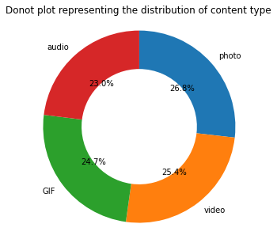

```python
# plotting m_gender using a donot plot
def contenttype():
    sol_string = ["I've used matplotlib's donot plot to depict the relative frequency of the content type of the .",
                      "My donot shows photo content as top, closely followed by video, gif and audio"]

    print((" ").join(sol_string))
    plt.figure(figsize = [8,5])
    sorted_counts = socialbuzz['c_type'].value_counts()
    plt.pie(sorted_counts, labels = sorted_counts.index, startangle = 90,autopct='%1.1f%%',counterclock = False, wedgeprops = {'width' : 0.4});
    plt.axis('square');
    plt.title('Donot plot representing the distribution of content type')

contenttype()
```

#### Distribution of reaction sentiment

```
I've used matplotlib to plot a pie chart to depict the relative frequency between the 3 reaction sentiment. My pie chart shows that positive sentiments are more than negative and neutral
```

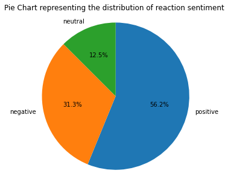

```python
# plotting m_gender using a donot plot
def reactionsentiment():
    sol_string = ["I've used matplotlib to plot a pie chart to depict the relative frequency between the 3 reaction sentiment.",
                      "My pie chart shows that positive sentiments are more than negative and neutral"]

    print((" ").join(sol_string))
    plt.figure(figsize=[8,5])
    sorted_counts = socialbuzz['r_sentiment'].value_counts()
    plt.pie(sorted_counts, labels = sorted_counts.index, startangle = 90, autopct='%1.1f%%', counterclock = False);
    plt.axis('square')
    plt.title('Pie Chart representing the distribution of reaction sentiment ')

reactionsentiment()
```

## Insights

> Back to the main question... what were the top 5 most popular categories of posts?

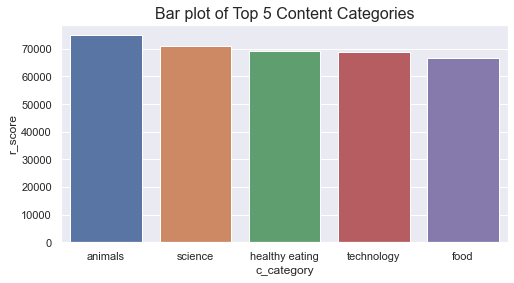

```python
sb.set(rc={'figure.figsize':(8,4)})

top5categories = socialbuzz.groupby('c_category', as_index=False)['r_score'].sum().sort_values(by='r_score', ascending=False).head(5)
sb.barplot(data=top5categories, x='c_category', y = 'r_score', dodge=False);
plt.title('Bar plot of Top 5 Content Categories', fontsize=16);
```

From our analysis, it can be seen from the bar chart that the top 5 most popular categories of posts were animals, science, healthy eating, technology and food in descending order. Animals had an aggregate popularity score of around 74,965. It is very interesting to see both food and healthy eating within the top 5, it really shows that food is a highly engaging content category. Healthy eating ranks slightly higher than food, so perhaps your user base may be skewed towards healthy eaters and health-conscious people. Finally, its also interesting to see science and technology too. This may suggest that people enjoy consuming factual content and snippets of content that they can learn something from

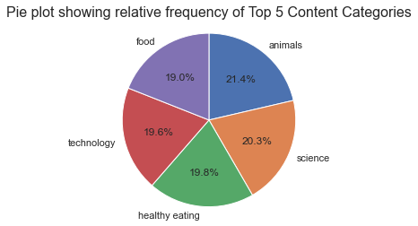

```python
sb.set(rc={'figure.figsize':(8,4)})
top5categories = socialbuzz.groupby('c_category', as_index=False)['r_score'].sum().sort_values(by='r_score', ascending=False).head(5)
plt.pie(data=top5categories, x='r_score',labels = 'c_category', startangle = 90, autopct='%1.1f%%', counterclock = False);
plt.axis('square')
plt.title('Pie plot showing relative frequency of Top 5 Content Categories', fontsize=16);
```

Furthermore, you can see from this pie chart the percentage split of popularity between the top 5 categories. There is not much difference between the share of each category, however, the difference between the 1st most popular, animals and the 2nd most popular, science, is the largest gap equal to 1.1%. In business terms, this could suggest that the most popular category, animals, is tailing away from the rest of the categories and may continue to get more and more popular. To avoid an issue where one content category consumes the entire platform, it will be important for you to ensure that any algorithms used to govern the content on the platform gives a fair balance to the content categories.

## Summary

In Summary, We tackled this task and found the top 5 most popular categories as asked, but we also went a step further. We discovered that animals and science are the two most popular categories, suggesting that users like "real-life" and "factual" content We also discovered that contents on food were amongst the most popular with healthy eating as the leading food category. This could be a pointer to the types of users of your platform, you could use this insight to boost engagement even further. For instance, you could run a campaign with content focused on food category or work with healthy eating brands As much as this analysis was insightful, I’ll recommend that you let us take it to the next stage - we have the expertise to help you realize these kinds of insights in production across your organization and we’d love to help you with this.

THANK YOU!!!